# Univariate Forecasts for min_temp_val and heat_days_val

In this part we need to evaluate univariate forecasts of the temperatures for the multiple linear regression. We will thus need to use the predicted values : - of min_temp_val and heat_days_val from February 2017 to July 2017 - of extreme_heat and extreme_cold from March 2017 to July 2017. Here, we will only predict min_temp_val and heat_days_val. In another notebook, we will predict extreme_heat and extreme_cold.

### Load the data

```r
library(readr)
temp <- na.omit(read_csv("data/temp.csv", col_types = cols(date = col_date(format = "%Y-%m-%d"))))
rmse <- function(l, r) {
  sqrt(sum((l - r)^2)/NROW(l))
}
exp_rmse <- function(l, r) {
  rmse(exp(l), exp(r))
}
```

# min_temp_val

### Stationarity and integration of the min_temp_val

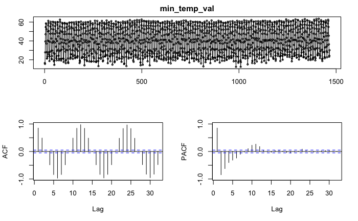

```r
library(forecast)
tsdisplay(temp$min_temp_val,main="min_temp_val")
```

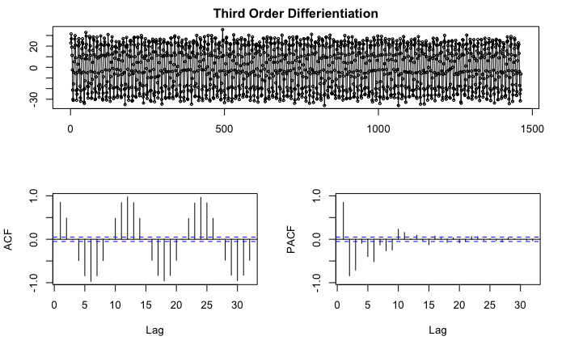

```r
tsdisplay(diff(temp$min_temp_val, 3), main="Third Order Differientiation")
```

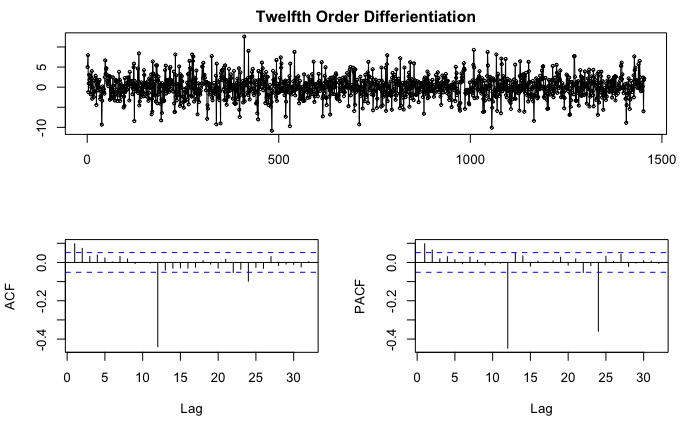

```r
tsdisplay(diff(temp$min_temp_val, 12), main="Twelfth Order Differientiation")
```

As we can see, we need to do a 12th order differenciation in order to remove the seasonality.

### Models evaluation

Let us convert data to a time series

```r
smin_temp_val = ts(temp$min_temp_val, start = c(1895, 1), frequency=12)
train = window(smin_temp_val, start = c(1895, 1), end = c(2016, 1))
test = window(smin_temp_val, start = c(2016,2), end = c(2017, 1))
```

## Simple Snaive

We first start with a simple seasonal naive process (ie. repetition of the last temporality).

```r
snaive = snaive(train, h = 12)
accuracy(snaive, test)
```

```
                     ME     RMSE      MAE        MPE     MAPE      MASE        ACF1 Theil's U
Training set 0.03825815 2.741758 2.022949 -0.4847231 6.877580 1.0000000  0.09912500        NA
Test set     0.58000000 2.850453 1.976667  1.4572188 6.514494 0.9771212 -0.08763248 0.3401596
```

## Time Series Decomposition with min_temp_val

Now for Time Series decomposition.

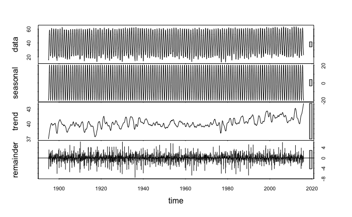

```r
decomp = stl(train, s.window="periodic")
plot(decomp)
```

As previously, our first attempt will just forecast the time series by removing seasonality, and then using the last observation to which we add back the seasonality as the next forecast value.

```r
stlfk_naive = forecast(decomp, method="naive", h=12)
summary(stlfk_naive)
```

```
Forecast method: STL +  Random walk

Model Information:
Call: rwf(y = x, h = h, drift = FALSE, level = level)

Residual sd: 2.6111

Error measures:
                      ME     RMSE      MAE        MPE     MAPE      MASE       ACF1
Training set 0.004180441 2.610229 1.899196 -0.5527495 6.405461 0.9388255 -0.4834527

Forecasts:
         Point Forecast    Lo 80    Hi 80     Lo 95    Hi 95
Feb 2016       25.32427 21.97912 28.66941 20.208313 30.44022
Mar 2016       32.65522 27.92447 37.38597 25.420169 39.89027
Apr 2016       41.31400 35.52004 47.10796 32.452906 50.17509
May 2016       50.13459 43.44431 56.82488 39.902686 60.36650
Jun 2016       58.35673 50.87676 65.83669 46.917104 69.79635
Jul 2016       63.22406 55.03017 71.41796 50.692587 75.75554
Aug 2016       61.74920 52.89879 70.59962 48.213662 75.28475
Sep 2016       54.59187 45.13037 64.05336 40.121762 69.06197
Oct 2016       44.04394 34.00851 54.07937 28.696079 59.39180
Nov 2016       33.35246 22.77419 43.93073 17.174395 49.53053
Dec 2016       25.30653 14.21195 36.40112  8.338831 42.27423
Jan 2017       22.59000 11.00209 34.17791  4.867814 40.31219
```

```r
accuracy(stlfk_naive, test)
```

```
                      ME     RMSE      MAE        MPE     MAPE      MASE       ACF1 Theil's U
Training set 0.004180441 2.610229 1.899196 -0.5527495 6.405461 0.9388255 -0.4834527        NA
Test set     0.548926772 1.817287 1.513659  1.7801928 4.484761 0.7482437  0.0176467 0.2646893
```

Let’s try with exponential smoothing to forecast the seasonally-adjusted series.

```r
stlfk_ets = forecast(decomp, method="ets", h=12)
summary(stlfk_ets)
```

```
Forecast method: STL +  ETS(A,N,N)

Model Information:
ETS(A,N,N)

Call:
 ets(y = x, model = etsmodel, allow.multiplicative.trend = allow.multiplicative.trend)

  Smoothing parameters:
    alpha = 0.0208

  Initial states:
    l = 39.4037

  sigma:  1.972

     AIC     AICc      BIC
12559.19 12559.21 12575.03

Error measures:
                     ME     RMSE      MAE        MPE     MAPE      MASE      ACF1
Training set 0.07265587 1.972015 1.458121 -0.4268779 5.006638 0.7207896 0.1041581

Forecasts:
         Point Forecast    Lo 80    Hi 80    Lo 95    Hi 95
Feb 2016       24.20707 21.67983 26.73431 20.34200 28.07215
Mar 2016       31.53803 29.01024 34.06581 27.67211 35.40394
Apr 2016       40.19681 37.66847 42.72514 36.33005 44.06356
May 2016       49.01740 46.48852 51.54628 45.14981 52.88499
Jun 2016       57.23953 54.71010 59.76896 53.37110 61.10796
Jul 2016       62.10687 59.57689 64.63685 58.23760 65.97614
Aug 2016       60.63201 58.10148 63.16254 56.76190 64.50212
Sep 2016       53.47467 50.94360 56.00575 49.60373 57.34562
Oct 2016       42.92675 40.39513 45.45837 39.05497 46.79853
Nov 2016       32.23527 29.70310 34.76744 28.36265 36.10789
Dec 2016       24.18934 21.65662 26.72206 20.31588 28.06279
Jan 2017       21.47281 18.93954 24.00607 17.59851 25.34710
```

```r
accuracy(stlfk_ets, test)
```

```
                     ME     RMSE      MAE        MPE     MAPE      MASE      ACF1 Theil's U
Training set 0.07265587 1.972015 1.458121 -0.4268779 5.006638 0.7207896 0.1041581        NA
Test set     1.66612019 2.403574 1.970577  4.6679047 5.648559 0.9741108 0.0176467 0.3538235
```

As a last attempt, we can also use arima on the seasonally-adjusted data.

```r
stlfk_arima = forecast(decomp, method="arima", h=12)
summary(stlfk_arima)
```

```
Forecast method: STL +  ARIMA(2,1,2) with drift

Model Information:
Series: x
ARIMA(2,1,2) with drift

Coefficients:
          ar1     ar2      ma1      ma2   drift
      -0.0162  0.0834  -0.8656  -0.1210  0.0015
s.e.   0.4742  0.0554   0.4762   0.4699  0.0008

sigma^2 estimated as 3.833:  log likelihood=-3034.98
AIC=6081.96   AICc=6082.02   BIC=6113.65

Error measures:
                     ME     RMSE      MAE        MPE    MAPE      MASE          ACF1
Training set 0.01816957 1.953752 1.443236 -0.5625857 4.95502 0.7134317 -6.348877e-05

Forecasts:
         Point Forecast    Lo 80    Hi 80    Lo 95    Hi 95
Feb 2016       24.66053 22.15151 27.16955 20.82331 28.49774
Mar 2016       31.61512 29.08863 34.14161 27.75118 35.47906
Apr 2016       40.22605 37.68838 42.76372 36.34502 44.10708
May 2016       49.01746 46.47920 51.55571 45.13553 52.89938
Jun 2016       57.23750 54.69871 59.77630 53.35475 61.12025
Jul 2016       62.10387 59.56481 64.64294 58.22071 65.98704
Aug 2016       60.63029 58.09095 63.16963 56.74670 64.51387
Sep 2016       53.47428 50.93469 56.01387 49.59031 57.35825
Oct 2016       42.92787 40.38803 45.46772 39.04351 46.81223
Nov 2016       32.23791 29.69781 34.77801 28.35317 36.12266
Dec 2016       24.19352 21.65316 26.73387 20.30838 28.07865
Jan 2017       21.47852 18.93791 24.01913 17.59300 25.36404
```

```r
accuracy(stlfk_arima, test)
```

```
                     ME     RMSE      MAE        MPE    MAPE      MASE          ACF1 Theil's U
Training set 0.01816957 1.953752 1.443236 -0.5625857 4.95502 0.7134317 -6.348877e-05        NA
Test set     1.61892314 2.332963 1.924086  4.5061107 5.48978 0.9511289 -1.861718e-02 0.3507002
```

R picked an ARIMA(2,1,2).

The best model for now when we consider RMSE on the Test set is the STL + Random walk.

## Seasonal ARIMA

```r
autofit = auto.arima(train, seasonal=TRUE)
```

Let us now try with our own seasonal ARIMA. Based on the ACF PACF of the annual differentiation, we try with an ARIMA(1,0,5)(0,0,2).

### Custom Seasonal Arima on the data

```r
custfit = Arima(train, order=c(1,0,5), seasonal=c(0,0,2))
print(custfit)
```

```
Series: train
ARIMA(1,0,5)(0,0,2)[12] with non-zero mean

Coefficients:
         ar1     ma1     ma2      ma3      ma4      ma5    sma1    sma2     mean
      0.6789  0.0600  0.0994  -0.3236  -0.4097  -0.3422  0.5631  0.3872  39.7177
s.e.  0.0468  0.0586  0.0408   0.0360   0.0454   0.0398  0.0489  0.0398   0.0957

sigma^2 estimated as 15.66:  log likelihood=-1443.92
AIC=2907.83   AICc=2908.27   BIC=2950.31
```

```r
custfk = forecast(custfit,h=12)
accuracy(custfk,test)
```

```
                      ME     RMSE      MAE        MPE     MAPE     MASE       ACF1 Theil's U
Training set -0.03058758 3.922147 3.120271 -3.4025390 10.27050 1.392264 0.04247043        NA
Test set      1.85268775 6.989635 5.895889 -0.8221263 15.36655 2.630745 0.74464334 0.9666341
```

Although the statistical tests and criterion seem better here, the error on train and test sets are higher, so we keep the STL + Random walk.

### Rolling Window Evaluation

To try more model, we would like to setup a rolling window. Let us find the optimal size of that window using the STL + Random walk we just fitted.

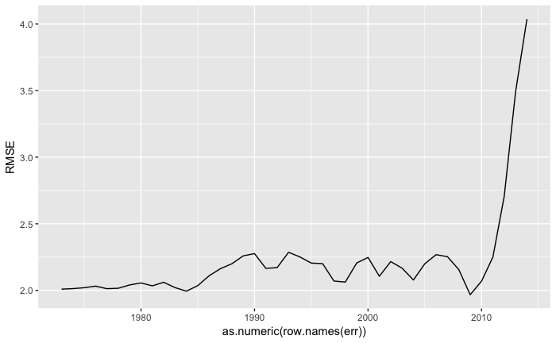

```r
library(ggplot2)
err = data.frame("RMSE" = rep(0, 2014-1973+1), row.names = seq(1973, 2014))
for (y in 1973:2014){
    model = stl(window(train, start=c(y,1)), s.window="periodic")
    rmse = accuracy(forecast(model, method="naive", h=12),test)[2,"RMSE"]
    err[as.character(y),] = rmse
}
ggplot(err)+geom_line(aes(x=as.numeric(row.names(err)), y=RMSE))
```

```r
ggplot(err)+geom_line(aes(x=as.numeric(row.names(err)), y=RMSE))+xlim(1950, 1980)
```

[output not shown]

```r
errm = data.frame("RMSE" = rep(0, 12), row.names = seq(1, 12))
for (m in 1:12){
    model = stl(window(train, start=c(1961,m)), s.window="periodic")
    rmse = accuracy(forecast(model, method="naive", h=12),test)[2,"RMSE"]
    errm[as.character(m),] = rmse
}
ggplot(errm)+geom_line(aes(x=as.numeric(row.names(errm)), y=RMSE))+scale_x_continuous(breaks=seq(1,12))
```

[output not shown]

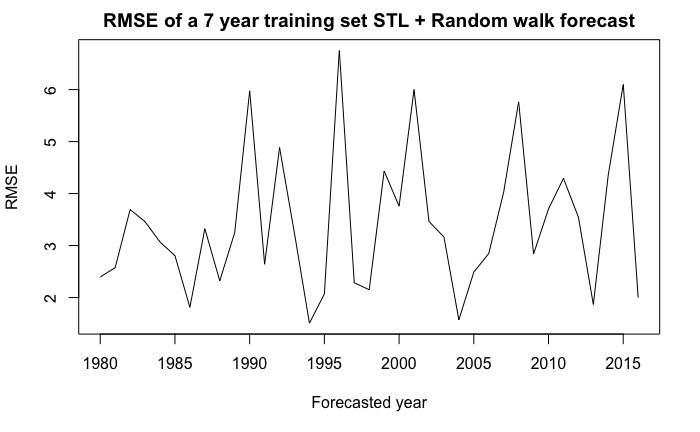

```r
plot(1980:2016, rollwitme(smin_temp_val), type = 'l', main = "RMSE of a 7 year training set STL + Random walk forecast", ylab = "RMSE", xlab = "Forecasted year")
```

[output not shown]

```r
plot(1950:2016, rollwitme(smin_temp_val), type = 'l', main = "RMSE of a 55 year training set STL + Random walk forecast", ylab = "RMSE", xlab = "Forecasted year")
```

[output not shown]

We notice a huge variability in the forecast performances over time !

Creation of the needed forecast : from Feb. 2017 to Feb. 2018 (we will only use from Feb. to July 2017).

```r
train_final = window(smin_temp_val, start=c(1962,2), end=c(1962+55,1))
model = stl(train_final, s.window="periodic")
yearly_forecast = forecast(model, method="naive", h=12)
plot(yearly_forecast)
```

[output not shown]

# heat_days_val

### Stationarity and integration of the heat_days_val

```r
library(forecast)
tsdisplay(temp$heat_days_val,main="heat_days_val")
tsdisplay(diff(temp$heat_days_val, 3), main="Third Order Differientiation")
tsdisplay(diff(temp$heat_days_val, 12), main="Twelfth Order Differientiation")
```

[output not shown]

As previously, we need to do a 12th order differenciation in order to remove the seasonality.

### Models evaluation

Let us convert data to a time series

```r
sheat_days_val = ts(temp$heat_days_val, start = c(1895, 1), frequency=12)
train = window(sheat_days_val, start = c(1895, 1), end = c(2016, 1))
test = window(sheat_days_val, start = c(2016,2), end = c(2017, 1))
```

## Simple Snaive

We first start with a simple seasonal naive process (ie. repetition of the last temporality).

```r
snaive = snaive(train, h = 12)
accuracy(snaive, test)
```

[output not shown]

Now for Time Series decomposition.

```r
decomp = stl(train, s.window="periodic")
plot(decomp)
```

[output not shown]

As previously, our first attempt will just forecast the time series by removing seasonality, and then using the last observation to which we add back the seasonality as the next forecast value.

```r
stlfk_naive = forecast(decomp, method="naive", h=12)
summary(stlfk_naive)
accuracy(stlfk_naive, test)
```

[output not shown]

Let’s try with exponential smoothing to forecast the seasonally-adjusted series.

```r
stlfk_ets = forecast(decomp, method="ets", h=12)
summary(stlfk_ets)
accuracy(stlfk_ets, test)
```

[output not shown]

As a last attempt, we can also use arima on the seasonally-adjusted data.

```r
stlfk_arima = forecast(decomp, method="arima", h=12)
summary(stlfk_arima)
accuracy(stlfk_arima, test)
```

[output not shown]

## Seasonal ARIMA

We first look at the auto.arima output.

```r
autofit = auto.arima(train, seasonal=TRUE)
print(autofit)
autofk = forecast(autofit,h=12)
accuracy(autofk,test)
```

[output not shown]

Let us now try with our own seasonal ARIMA. Based on the ACF PACF of the annual differentiation, we try with an ARIMA(1,0,5)(0,0,2).

### Custom Seasonal Arima on the data

```r
custfit = Arima(train, order=c(1,0,5), seasonal=c(0,0,2))
print(custfit)
custfk = forecast(custfit,h=12)
accuracy(custfk,test)
```

[output not shown]

### Rolling Window Evaluation

To try more model, we would like to setup a rolling window. Let us find the optimal size of that window using the STL + Random walk we just fitted.

```r
library(ggplot2)
err = data.frame("RMSE" = rep(0, 2014-1895+1), row.names = seq(1895, 2014))
for (y in 1895:2014){
    model = stl(window(train, start=c(y,1)), s.window="periodic")
    rmse = accuracy(forecast(model, method="naive", h=12),test)[2,"RMSE"]
    err[as.character(y),] = rmse
}
ggplot(err)+geom_line(aes(x=as.numeric(row.names(err)), y=RMSE))
```

[output not shown]

Let us take a closer look at the years between 1950 and 1980.

```r
ggplot(err)+geom_line(aes(x=as.numeric(row.names(err)), y=RMSE))+xlim(1950, 1980)
```

[output not shown]

Let us take a closer look at the year 1976.

```r
errm = data.frame("RMSE" = rep(0, 12), row.names = seq(1, 12))
for (m in 1:12){
    model = stl(window(train, start=c(1976,m)), s.window="periodic")
    rmse = accuracy(forecast(model, method="naive", h=12),test)[2,"RMSE"]
    errm[as.character(m),] = rmse
}
ggplot(errm)+geom_line(aes(x=as.numeric(row.names(errm)), y=RMSE))+scale_x_continuous(breaks=seq(1,12))
```

[output not shown]

We will still use a rolling window of 40 full years !

```r
rollwitme = function(lgas){
    RMSE = rep(0,81)
    for (y in 1895:1976){
        tr = window(lgas, start=c(y,2), end=c(y+39,1))
        te = window(lgas, start=c(y+39,2), end=c(y+40,1))
        model = stl(tr, s.window="periodic")
        RMSE[y+1-1895] = accuracy(forecast(model, method="naive", h=12),te)[2,"RMSE"]
    }
    return(RMSE)
}
```

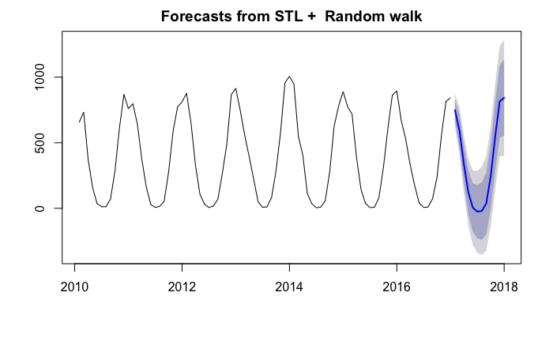

```r
train_final = window(sheat_days_val, start=c(2010,2), end=c(2010+7,1))
model = stl(train_final, s.window="periodic")
yearly_forecast = forecast(model, method="naive", h=12)
plot(yearly_forecast)
```

```r
train_final = window(sheat_days_val, start=c(1977,3), end=c(1977+40,2))
model = stl(train_final, s.window="periodic")
yearly_forecast = forecast(model, method="naive", h=12)
plot(yearly_forecast)
```

[output not shown]

Warning : Since here there are negative predictions, we will replace all negative predictions with 0 !